# Piotr Bajger - Etap 1.

Piotr Bajger

3 kwietnia 2017

## 1.1. Wczytanie i przygotowanie danych

Celem Etapu 1. jest przygotowanie danych oraz skonstruowanie modelu predykcji czasu potrzebnego na rozwiązanie zadania z części matematycznej testu PISA 2015 na podstawie ID zadania oraz jego pozycji w kwestionariuszu.

Dane pochodzą z pliku **actionTimeScoreMath.rda**. Będziemy korzystać jedynie ze zmiennych *T*, *CNTSTUID*, *position* oraz *item_short*. Rozpoczniemy od wczytania zbioru danych oraz usunięcia wybrakowanych obserwacji, tzn. takich, dla których:

- zmienna *T*, *CNTSTUID*, *position* lub *item_short* przyjmuje wartość *NA*.
- zmienna *position* przyjmuje wartość *-1*.

Następnie wyodrębniamy z *item_short* ID zadania (pierwsze cztery znaki) i zapisujemy jako nową zmienną *question*.

Przeprowadzamy agregację, tzn. dla każdej pary (*CNTSTUID*, *question*) sumujemy czas *T*, by znaleźć całkowity czas, który uczeń poświęcił‚ na rozwiązanie zadania. Dołączamy do zagregowanych w ten sposób danych zmienną *position*. Usuwamy zmienne, które nie są przedmiotem naszej analizy i otrzymujemy w ten sposób zbiór **qTimeFinal**.

Badamy rozkład zmiennej *T*:

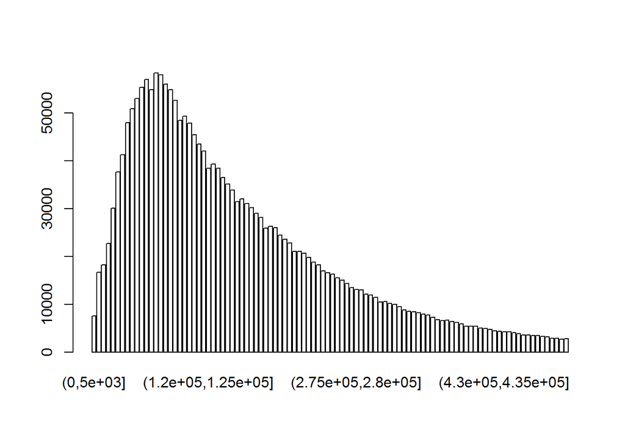

```r
barplot(with(qTimeFinal, table(T.cut)), col="white")
```

Rozkład sugeruje transformację *T* -> *log(T)*. Widzimy, że przetransformowany czas ma istotnie rozkład zbliżony do normalnego (najlepsze dopasowanie zaznaczone na czerwono).

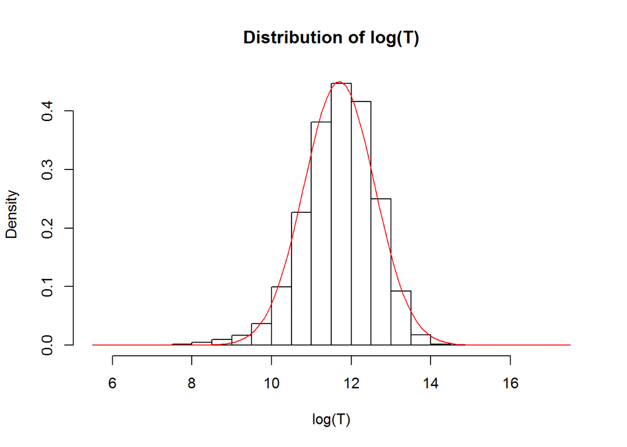

[output not shown]

```r
qTimeFinal$logT = log(qTimeFinal$T)
fit <- fitdistr(qTimeFinal$logT, "normal")
h = hist(qTimeFinal$logT, prob = TRUE, xlab="log(T)", main="Distribution of log(T)")
curve(dnorm(x, fit$estimate[1], fit$estimate[2]), col=2, add=TRUE)
```

## 1.2. Konstrukcja modeli liniowych

Mając w ten sposób przygotowane dane możemy przejść do konstrukcji właściwego modelu. Będziemy przewidywali (zlogarytmizowany) czas (*logT*) potrzebny na rozwiązanie zadadnia na podstawie ID zadania (*question*) oraz jego pozycji w teście (*position*). Rozważamy następujące modele liniowe uzależniające zlogarytmizowany czas od:

- model1: Pozycji w teście oraz ID zadania.
- model2: ID zadania zagnieżdżonego w pozycji w teście.

```r
model1 <- lm(logT~as.factor(position)+question, data=qTimeFinal)
model2 <- lm(logT~as.factor(position)/question, data=qTimeFinal)
```

Testy ANOVA sugerująz że w obu przypadkach występują statystycznie istotne różnice pomiędzy średnimi w podpopulacjach, toteż uzasadnione jest użycie obu zmiennych. W Etapie 2. będziemy kontynuować analizę powyższych modeli.

```r
anova(model1)
```

```
## Analysis of Variance Table
##
## Response: logT
##                          Df  Sum Sq Mean Sq F value    Pr(>F)
## as.factor(position)       3   31131 10376.9   21813 < 2.2e-16 ***
## question                 44  655162 14890.0   31300 < 2.2e-16 ***
## Residuals           2212422 1052495     0.5
## ---
## Signif. codes:  0 '***' 0.001 '**' 0.01 '*' 0.05 '.' 0.1 ' ' 1
```

```r
anova(model2)
```

```
## Analysis of Variance Table
##
## Response: logT
##                                   Df  Sum Sq Mean Sq F value    Pr(>F)
## as.factor(position)                3   31131 10376.9 21957.0 < 2.2e-16 ***
## as.factor(position):question     176  662129  3762.1  7960.4 < 2.2e-16 ***
## Residuals                    2212290 1045528     0.5
## ---
## Signif. codes:  0 '***' 0.001 '**' 0.01 '*' 0.05 '.' 0.1 ' ' 1
```